# group13model

group13

2023-03-16

# Data Loading and Pre-processing

## Removing Value

We noticed missing data and outliers in the data cleaning section, so we removed them before building our model.

```r
dataset13 <- read_csv("dataset13.csv")
newdataset<- na.omit(dataset13)
newdataset<- newdataset%>%
  arrange(desc(altitude_mean_meters))
newdataset<- newdataset[-c(1:4),]
newdataset<- newdataset%>%
  arrange(aroma)
newdataset<- newdataset[-1,]
str(newdataset)
```

[output not shown]

## Calculating Correlation

In order to prepare for subsequent improvement and selection of variables during modelling, we firstly calculated the correlation between every two numerical variables.

```r
newdataset[,2:6]%>%
  cor()%>%
  kable(caption='\\label{tab:correlation} correlation between 5 numerical variables')%>%
  kable_styling(font_size = 10, latex_options = "hold_position")
```

correlation between 5 numerical variables

|  | aroma | flavor | acidity | category_two_defects | altitude_mean_meters |
| --- | --- | --- | --- | --- | --- |
| aroma | 1.0000000 | 0.7253135 | 0.5907547 | -0.1934092 | 0.1632542 |
| flavor | 0.7253135 | 1.0000000 | 0.7438336 | -0.2477485 | 0.1476604 |
| acidity | 0.5907547 | 0.7438336 | 1.0000000 | -0.1851076 | 0.1778057 |
| category_two_defects | -0.1934092 | -0.2477485 | -0.1851076 | 1.0000000 | -0.0025717 |
| altitude_mean_meters | 0.1632542 | 0.1476604 | 0.1778057 | -0.0025717 | 1.0000000 |

Table $\ref{tab:correlation}$ shows the correlation between every two variables including aroma,flavor,acidity,category_two_defects and altitude_mean_meters.We can see that the correlation between aroma and flavor (0.72) and the correlation between flavor acidity (0.74) are both more than 0.7, which means they are of strong positive correlation, there is also a moderate correlation between aroma and acidity (0.59), while the correlation between other pairs are relatively weak.

## Processing Non-numerical Data

For non-numerical data, including country_of_origin, Qualityclass and harvested, we set the country_of_origin and harvested as factors, while as a qualitative variable, we converted Qualityclass into dummy variables, ‘poor’ to ‘0’ and ‘good’ to ‘1’.

```r
names(newdataset)
newdataset$country_of_origin<- as.factor(newdataset$country_of_origin)
newdataset$Qualityclass<- ifelse(newdataset$Qualityclass=='Poor',0,1)
newdataset$harvested <- as.factor(newdataset$harvested)
```

[output not shown]

# Formal Data Analysis

## Basic GLM

```r
mod.cafe <- glm(Qualityclass ~  country_of_origin +aroma + flavor+acidity+category_two_defects+altitude_mean_meters+harvested, data = newdataset,
                family = binomial(link = "logit"))
mod.cafe %>%
  summary()#AIC 543
```

```
Call:
glm(formula = Qualityclass ~ country_of_origin + aroma + flavor +
    acidity + category_two_defects + altitude_mean_meters + harvested,
    family = binomial(link = "logit"), data = newdataset)

Deviance Residuals:
    Min       1Q   Median       3Q      Max
-4.5339  -0.2406   0.0000   0.2851   3.6011

Coefficients:
                                                Estimate Std. Error z value
(Intercept)                                   -1.446e+02  1.164e+01 -12.416
country_of_originBurundi                       1.908e+00  4.926e+00   0.387
country_of_originChina                         4.996e-01  1.081e+00   0.462
country_of_originColombia                      1.816e+00  5.642e-01   3.218
country_of_originCosta Rica                    2.898e-01  7.635e-01   0.380
country_of_originCote d?Ivoire                -1.211e+01  6.523e+03  -0.002
country_of_originEcuador                      -1.427e+00  1.495e+00  -0.954
country_of_originEl Salvador                   5.411e-01  9.579e-01   0.565
country_of_originEthiopia                      1.333e+01  8.981e+02   0.015
country_of_originGuatemala                    -5.834e-01  5.456e-01  -1.069
country_of_originHaiti                         2.125e+00  1.788e+00   1.189
country_of_originHonduras                     -3.959e-01  6.791e-01  -0.583
country_of_originIndia                        -2.988e+00  1.085e+00  -2.754
country_of_originIndonesia                    -1.188e-01  9.863e-01  -0.120
country_of_originKenya                         6.488e-01  1.596e+00   0.406
country_of_originLaos                         -1.513e+01  4.504e+03  -0.003
country_of_originMalawi                       -8.307e-01  1.284e+00  -0.647
country_of_originMauritius                    -1.206e+01  6.523e+03  -0.002
country_of_originMexico                       -6.986e-01  5.074e-01  -1.377
country_of_originMyanmar                      -1.634e+01  2.361e+03  -0.007
country_of_originNicaragua                     5.066e-01  1.977e+00   0.256
country_of_originPanama                        3.344e+00  1.820e+00   1.837
country_of_originPeru                         -1.416e+01  6.523e+03  -0.002
country_of_originPhilippines                   2.892e+00  2.778e+00   1.041
country_of_originTaiwan                        7.848e-01  6.631e-01   1.184
country_of_originTanzania, United Republic Of  1.023e+00  7.536e-01   1.358
country_of_originThailand                      2.560e+00  9.800e-01   2.612
country_of_originUganda                       -1.550e+00  7.903e-01  -1.962
country_of_originUnited States                -3.077e-01  1.678e+00  -0.183
```

[output cut: 59 more lines]

```
harvested2014                                  0.96655
harvested2015                                  0.94595
harvested2016                                  0.46625
harvested2017                                  0.62654
harvested2018                                  0.10876
---
Signif. codes:  0 '***' 0.001 '**' 0.01 '*' 0.05 '.' 0.1 ' ' 1

(Dispersion parameter for binomial family taken to be 1)

    Null deviance: 1289.15  on 929  degrees of freedom
Residual deviance:  451.69  on 884  degrees of freedom
AIC: 543.69

Number of Fisher Scoring iterations: 17
```

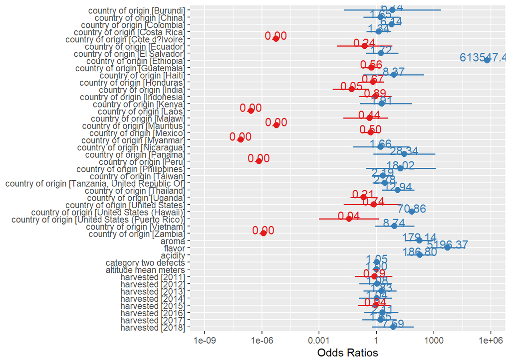

Odds of various factors influencing the quality of coffee(basic GLM model)

```r
plot_model(mod.cafe, show.values = TRUE,
           title = "", show.p = FALSE, value.offset = 0.5)
```

## GLM Stepwise

```r
# Fit a glm using stepwise regression with AIC as the criterion
model.step <- stepAIC(glm(Qualityclass ~  country_of_origin +aroma + flavor+acidity+category_two_defects+altitude_mean_meters+harvested, data = newdataset, family = binomial(link = "logit")), direction = "both", trace = FALSE)
```

```r
# Print the selected model
summary(model.step)#AIC 537
```

```
Call:
glm(formula = Qualityclass ~ country_of_origin + aroma + flavor +
    acidity + category_two_defects + altitude_mean_meters, family = binomial(link = "logit"),
    data = newdataset)

Deviance Residuals:
    Min       1Q   Median       3Q      Max
-4.4436  -0.2581   0.0000   0.2879   3.6167

Coefficients:
                                                Estimate Std. Error z value
(Intercept)                                   -1.394e+02  1.098e+01 -12.704
country_of_originBurundi                       1.782e+00  5.233e+00   0.341
country_of_originChina                        -5.403e-02  1.010e+00  -0.053
country_of_originColombia                      1.591e+00  5.253e-01   3.029
country_of_originCosta Rica                    6.447e-02  7.137e-01   0.090
country_of_originCote d?Ivoire                -1.209e+01  6.523e+03  -0.002
country_of_originEcuador                      -1.385e+00  1.476e+00  -0.938
country_of_originEl Salvador                   4.678e-01  9.419e-01   0.497
country_of_originEthiopia                      1.348e+01  8.855e+02   0.015
country_of_originGuatemala                    -7.760e-01  4.969e-01  -1.562
country_of_originHaiti                         1.836e+00  1.850e+00   0.993
country_of_originHonduras                     -5.148e-01  6.293e-01  -0.818
country_of_originIndia                        -3.288e+00  1.031e+00  -3.188
country_of_originIndonesia                    -5.109e-01  9.029e-01  -0.566
country_of_originKenya                         8.836e-01  1.459e+00   0.606
country_of_originLaos                         -1.560e+01  4.385e+03  -0.004
country_of_originMalawi                       -1.301e+00  1.218e+00  -1.069
country_of_originMauritius                    -1.212e+01  6.523e+03  -0.002
country_of_originMexico                       -1.043e+00  4.456e-01  -2.340
country_of_originMyanmar                      -1.680e+01  2.378e+03  -0.007
country_of_originNicaragua                     2.176e-01  1.954e+00   0.111
country_of_originPanama                        2.756e+00  1.787e+00   1.542
country_of_originPeru                         -1.467e+01  6.523e+03  -0.002
country_of_originPhilippines                   2.294e+00  2.663e+00   0.861
country_of_originTaiwan                        4.300e-01  6.082e-01   0.707
country_of_originTanzania, United Republic Of  6.665e-01  7.035e-01   0.947
country_of_originThailand                      1.992e+00  9.186e-01   2.168
country_of_originUganda                       -1.580e+00  7.415e-01  -2.130
country_of_originUnited States                -6.488e-01  1.594e+00  -0.407
```

[output cut: 43 more lines]

```
aroma                                         1.88e-09 ***
flavor                                        1.65e-15 ***
acidity                                       1.71e-11 ***
category_two_defects                           0.14466
altitude_mean_meters                           0.13285
---
Signif. codes:  0 '***' 0.001 '**' 0.01 '*' 0.05 '.' 0.1 ' ' 1

(Dispersion parameter for binomial family taken to be 1)

    Null deviance: 1289.1  on 929  degrees of freedom
Residual deviance:  461.7  on 892  degrees of freedom
AIC: 537.7

Number of Fisher Scoring iterations: 17
```

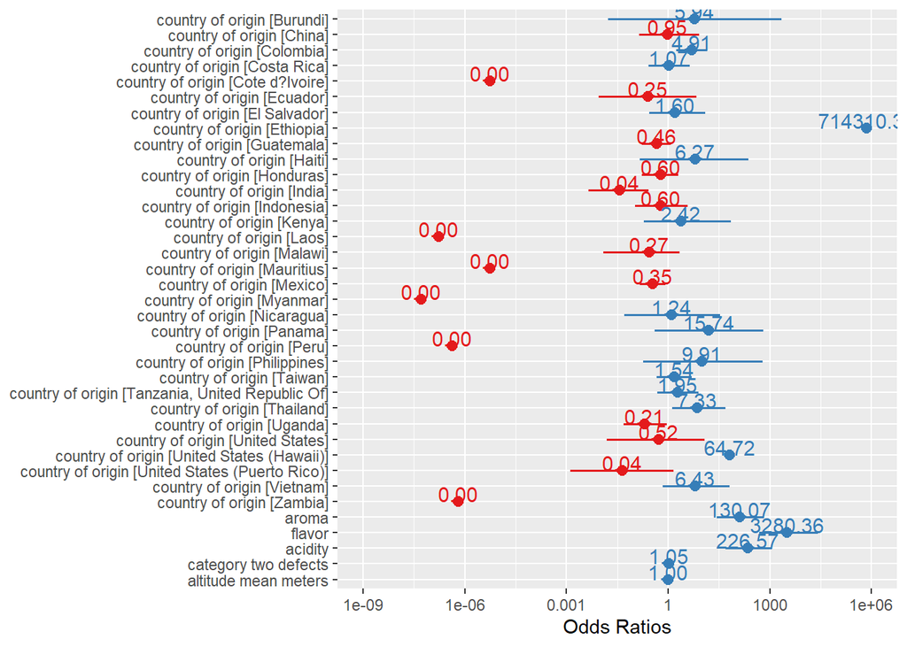

Odds of various factors influencing the quality of coffee(GLM stepwise regression)

```r
plot_model(model.step, show.values = TRUE,
           title = "", show.p = FALSE, value.offset = 0.50)
```

## Adding Interaction Terms

```r
mod.cafe <- glm(Qualityclass ~  country_of_origin +aroma + flavor+acidity+category_two_defects+altitude_mean_meters+harvested+aroma:flavor+flavor:acidity+aroma:acidity, data = newdataset,
                   family = binomial(link = "logit"))
mod.cafe %>%
  summary() #AIC 539
```

```
Call:
glm(formula = Qualityclass ~ country_of_origin + aroma + flavor +
    acidity + category_two_defects + altitude_mean_meters + harvested +
    aroma:flavor + flavor:acidity + aroma:acidity, family = binomial(link = "logit"),
    data = newdataset)

Deviance Residuals:
    Min       1Q   Median       3Q      Max
-3.6032  -0.1769   0.0000   0.2996   4.2438

Coefficients:
                                                Estimate Std. Error z value
(Intercept)                                   -1.185e+03  3.116e+02  -3.802
country_of_originBurundi                       3.297e+00  9.721e+00   0.339
country_of_originChina                         4.982e-01  1.079e+00   0.462
country_of_originColombia                      1.779e+00  5.819e-01   3.057
country_of_originCosta Rica                    9.846e-02  7.742e-01   0.127
country_of_originCote d?Ivoire                -1.037e+01  6.523e+03  -0.002
country_of_originEcuador                      -1.507e+00  1.507e+00  -1.000
country_of_originEl Salvador                   5.435e-01  9.684e-01   0.561
country_of_originEthiopia                      1.457e+01  6.167e+02   0.024
country_of_originGuatemala                    -5.908e-01  5.565e-01  -1.061
country_of_originHaiti                         2.546e+00  2.021e+00   1.260
country_of_originHonduras                     -3.395e-01  6.967e-01  -0.487
country_of_originIndia                        -2.671e+00  1.028e+00  -2.598
country_of_originIndonesia                    -1.766e-01  1.005e+00  -0.176
country_of_originKenya                         7.890e-01  1.583e+00   0.498
country_of_originLaos                         -1.456e+01  4.430e+03  -0.003
country_of_originMalawi                       -8.767e-01  1.308e+00  -0.670
country_of_originMauritius                    -9.658e+00  6.523e+03  -0.001
country_of_originMexico                       -7.121e-01  5.147e-01  -1.383
country_of_originMyanmar                      -1.701e+01  2.242e+03  -0.008
country_of_originNicaragua                     8.465e-01  2.158e+00   0.392
country_of_originPanama                        4.297e+00  2.199e+00   1.954
country_of_originPeru                         -1.417e+01  6.523e+03  -0.002
country_of_originPhilippines                   3.977e+00  4.846e+00   0.821
country_of_originTaiwan                        8.445e-01  6.920e-01   1.220
country_of_originTanzania, United Republic Of  1.122e+00  7.978e-01   1.407
country_of_originThailand                      2.870e+00  1.094e+00   2.623
country_of_originUganda                       -1.560e+00  7.724e-01  -2.020
```

[output cut: 66 more lines]

```
harvested2017                                 0.578065
harvested2018                                 0.085370 .
aroma:flavor                                  0.006502 **
flavor:acidity                                0.540886
aroma:acidity                                 0.433933
---
Signif. codes:  0 '***' 0.001 '**' 0.01 '*' 0.05 '.' 0.1 ' ' 1

(Dispersion parameter for binomial family taken to be 1)

    Null deviance: 1289.15  on 929  degrees of freedom
Residual deviance:  441.86  on 881  degrees of freedom
AIC: 539.86

Number of Fisher Scoring iterations: 17
```

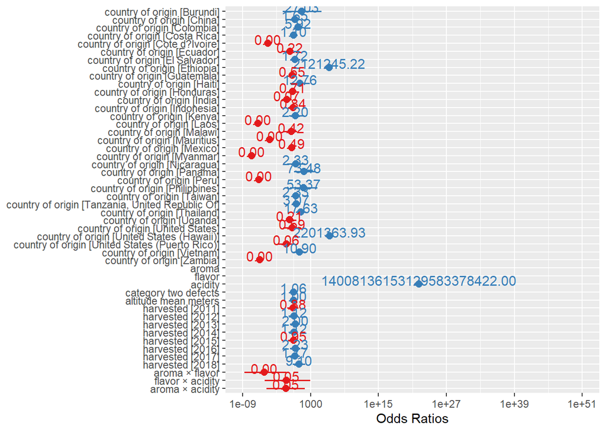

Odds of various factors influencing the quality of coffee(model with interaction terms)

```r
plot_model(mod.cafe, show.values = TRUE,
           title = "", show.p = FALSE, value.offset = 0.5)
```

In the results we can see the coefficients of aroma, flavor and acidity themselves are significantly positive, while the coefficients of all our possible interaction terms are negative,which shows that these three variables may moderate each other.After adding interaction terms, we can find that the AIC of the model decreases compared to the basic model, thus we can assume that the addition of the interaction terms improved our model.

## GLM Stepwise After Adding Interaction Terms

In order to further improve our model, we fitted the GLM model with interaction terms using the method of stepwise regression with AIC as the criterion.

```r
model.step <- stepAIC(glm(Qualityclass ~  country_of_origin +aroma + flavor+acidity+category_two_defects+altitude_mean_meters+harvested+aroma:flavor+flavor:acidity+aroma:acidity, data = newdataset, family = binomial(link = "logit")), direction = "both", trace = FALSE)
```

```r
summary(model.step)#AIC 532
```

```
Call:
glm(formula = Qualityclass ~ country_of_origin + aroma + flavor +
    acidity + category_two_defects + altitude_mean_meters + aroma:flavor,
    family = binomial(link = "logit"), data = newdataset)

Deviance Residuals:
    Min       1Q   Median       3Q      Max
-3.9820  -0.2105   0.0000   0.3028   4.0087

Coefficients:
                                                Estimate Std. Error z value
(Intercept)                                   -8.562e+02  2.371e+02  -3.611
country_of_originBurundi                       2.913e+00  8.893e+00   0.328
country_of_originChina                        -9.595e-02  1.003e+00  -0.096
country_of_originColombia                      1.555e+00  5.331e-01   2.916
country_of_originCosta Rica                   -8.522e-02  7.109e-01  -0.120
country_of_originCote d?Ivoire                -1.128e+01  6.523e+03  -0.002
country_of_originEcuador                      -1.427e+00  1.478e+00  -0.966
country_of_originEl Salvador                   5.754e-01  9.429e-01   0.610
country_of_originEthiopia                      1.351e+01  8.921e+02   0.015
country_of_originGuatemala                    -7.663e-01  5.035e-01  -1.522
country_of_originHaiti                         2.172e+00  2.070e+00   1.050
country_of_originHonduras                     -4.786e-01  6.397e-01  -0.748
country_of_originIndia                        -3.091e+00  1.010e+00  -3.059
country_of_originIndonesia                    -5.226e-01  9.031e-01  -0.579
country_of_originKenya                         9.363e-01  1.447e+00   0.647
country_of_originLaos                         -1.538e+01  4.351e+03  -0.004
country_of_originMalawi                       -1.320e+00  1.226e+00  -1.077
country_of_originMauritius                    -1.056e+01  6.523e+03  -0.002
country_of_originMexico                       -1.034e+00  4.493e-01  -2.301
country_of_originMyanmar                      -1.762e+01  2.219e+03  -0.008
country_of_originNicaragua                     4.554e-01  2.094e+00   0.217
country_of_originPanama                        3.525e+00  2.013e+00   1.751
country_of_originPeru                         -1.503e+01  6.523e+03  -0.002
country_of_originPhilippines                   3.048e+00  4.026e+00   0.757
country_of_originTaiwan                        4.863e-01  6.171e-01   0.788
country_of_originTanzania, United Republic Of  7.334e-01  7.299e-01   1.005
country_of_originThailand                      2.321e+00  1.012e+00   2.293
country_of_originUganda                       -1.560e+00  7.188e-01  -2.170
country_of_originUnited States                -8.667e-01  1.708e+00  -0.508
```

[output cut: 45 more lines]

```
flavor                                        0.000940 ***
acidity                                       3.58e-11 ***
category_two_defects                          0.149891
altitude_mean_meters                          0.090431 .
aroma:flavor                                  0.002178 **
---
Signif. codes:  0 '***' 0.001 '**' 0.01 '*' 0.05 '.' 0.1 ' ' 1

(Dispersion parameter for binomial family taken to be 1)

    Null deviance: 1289.15  on 929  degrees of freedom
Residual deviance:  454.12  on 891  degrees of freedom
AIC: 532.12

Number of Fisher Scoring iterations: 17
```

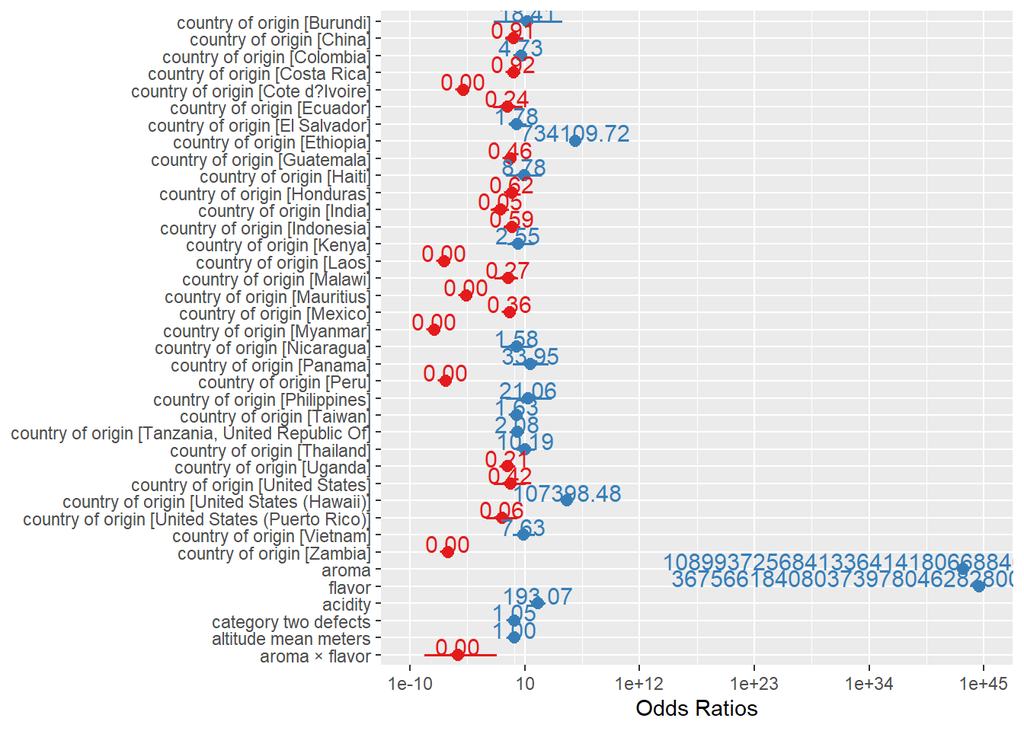

Odds of various factors influencing the quality of coffee(stepwise regression with interaction terms)

```r
plot_model(model.step, show.values = TRUE,
           title = "", show.p = FALSE, value.offset = 0.50)
```

We can see from the results that the AIC decreased to the lowest among these four models we fitted. AS AIC balances simplicity and accuracy when evaluating models, we can say that after adding an interaction term and doing the stepwise regression, our fourth model is the best model. Also, the last model has the lowest BIC=720, while the other three are 766,721,776 separately, which further demonstrates the superiority of our model.

```r
levels(newdataset$country_of_origin)
```

```
 [1] "Brazil"                       "Burundi"
 [3] "China"                        "Colombia"
 [5] "Costa Rica"                   "Cote d?Ivoire"
 [7] "Ecuador"                      "El Salvador"
 [9] "Ethiopia"                     "Guatemala"
[11] "Haiti"                        "Honduras"
[13] "India"                        "Indonesia"
[15] "Kenya"                        "Laos"
[17] "Malawi"                       "Mauritius"
[19] "Mexico"                       "Myanmar"
[21] "Nicaragua"                    "Panama"
[23] "Peru"                         "Philippines"
[25] "Taiwan"                       "Tanzania, United Republic Of"
[27] "Thailand"                     "Uganda"
[29] "United States"                "United States (Hawaii)"
[31] "United States (Puerto Rico)"  "Vietnam"
[33] "Zambia"
```

# checking assumptions

## Residuals Plots for each variables

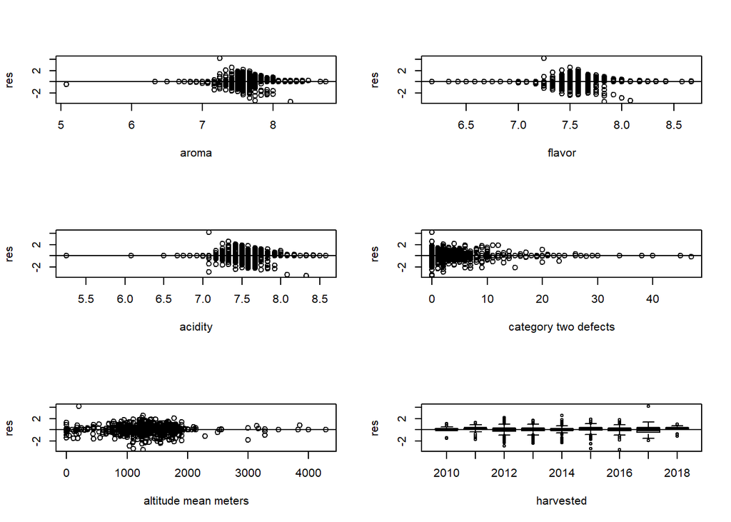

residuals against each variables

```r
res <- resid(mod.cafe)
par(mfrow=c(3,2))
plot(newdataset$aroma,res,xlab='aroma')
abline(0,0)
plot(newdataset$flavor,res,xlab='flavor')
abline(0,0)
plot(newdataset$acidity,res,xlab='acidity')
abline(0,0)
plot(newdataset$category_two_defects,res,xlab='category two defects')
abline(0,0)
plot(newdataset$altitude_mean_meters,res,xlab='altitude mean meters')
abline(0,0)
plot(newdataset$harvested,res,xlab='harvested',ylab='res')
abline(0,0)
```

We see that there is an even spread of the residuals above and below the zero line for each variables,although there are a very few outlier points, overrall their spread on the graphs are acceptable, hence our assumption that the residuals have mean zero appears valid.

# Density Plot

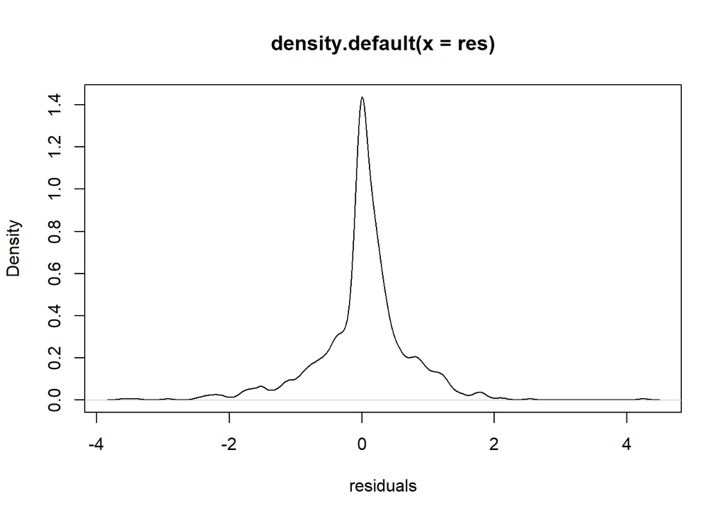

density plot of residuals

```r
plot(density(res),xlab='residuals',title='')
```

The remaining assumptions hold naturally at the time of our modelling, thus our model appears valid.

# Conclusion